# What Shapes Far-Right Discourses on Immigration? Analyzing 23 Years of Right-Wing Print Media in Germany

72nd Annual ICA Conference: Political Journalism in (Print) News Media and on Twitter

Christian S. Czymara

2022-05-27

## Research questions

- Anti-immigration positions are a core element of the political right
- Right-wing media is crucial part of right-wing discourse
- Immigration news of *Junge Freiheit* (JF)
- Goal 1: Analyze the content of articles in an explorative manner
- Goal 2: Test relationship between right-wing immigration news and real-world developments (Jacobs et al. 2018))
- Right-wing media most-likely case to politicize/problematize real-world developments

## Junge Freiheit

- Weekly newspaper founded in 1986, largest right-wing print outlet in Germany
- Between conservative and far-right, often bridging democratic conservatism and the extreme right
- “one of the sharpest weapons in the arsenal of the New Right” (Braun, Geisler, and Gerster 2007: 17)
- Fifth largest weekly newspaper in Germany, circulation of over 30,000 sold copies each quarter (IVW 2021)

# Data & Method

## Identifying articles about immigration

- Scraped web archive of Junge Freiheit
- Regular expressions using keywords
- Trained Naïve Bayes classifier based on hand-coded random sample of 600 articles (recall: 0.97, precision: 0.78)
- 5,695 positive predictions in overall data

## Development of published articles on immigration

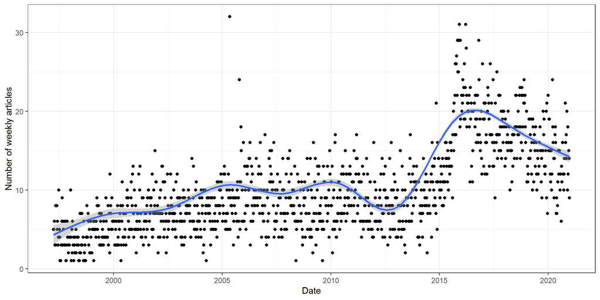

## Topic models

- Decompose immigration issue into its thematic subcomponents using Structural Topic Models (STM)
- STM identify word clusters (topics) in texts without restrictions (except for number of topics, here: 30)
- All topics consist of all terms, and all articles of all topics, but both with varying probability
- Modelling a shift in right-wing discursive priorities

## Real-world indicators

- Number of immigrants to Germany with non-EU citizenship (Eurostat)
- Islamist attacks w/ at least one casualty or injury in Western countries / in Germany (Fondapol 2021) in 2 weeks before article publication
- Share of reported crimes conducted by non-German suspects (BKA 2021)

# Results

## Immigration policy topic

- Terms: *mass immigration, uncontrolled*
- Example: *From dilemma to disaster - Immigration policy: Europe and Germany are not deporting too much, but too little* (Paulwitz in Junge Freiheit 43/13; 18 Oct 2013)

## Asylum topic

- Terms: *deportation, authorities*
- Example: *The difficult path to a “culture of goodbye”: Under pressure from the continuing influx of asylum seekers, the low number of deportations comes under criticism* (Persdorf in Junge Freiheit 41/15; 02 Oct 2015)

# Influence of real-world indicators

## Effect of immigration

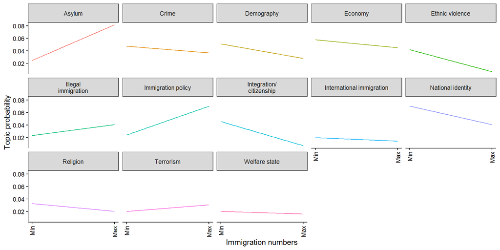

## Effect of terrorism

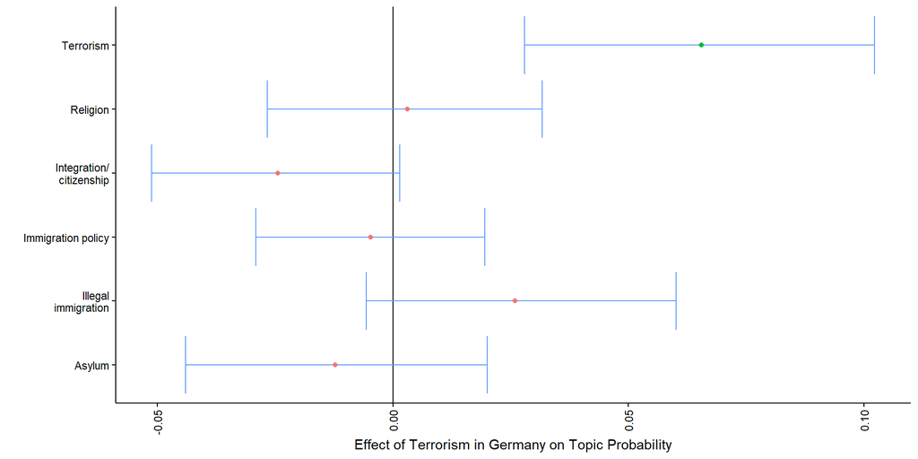

## Effect of crime

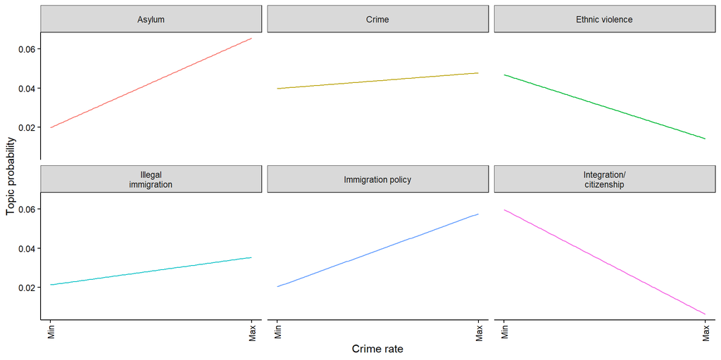

## Conclusion

- Reporting on immigration increased over time, peaking 2015/16
- Topics mostly in line with cultural, economic, and security threat
- Humanitarian topics practically absent
- Content hardly connected to real-world indicators (also see Jacobs et al. 2018)
- Two exceptions: Terror attacks (esp. in Germany) and refugee immigration of 2015/16
- Event based reporting style

# Appendix

## Circulation

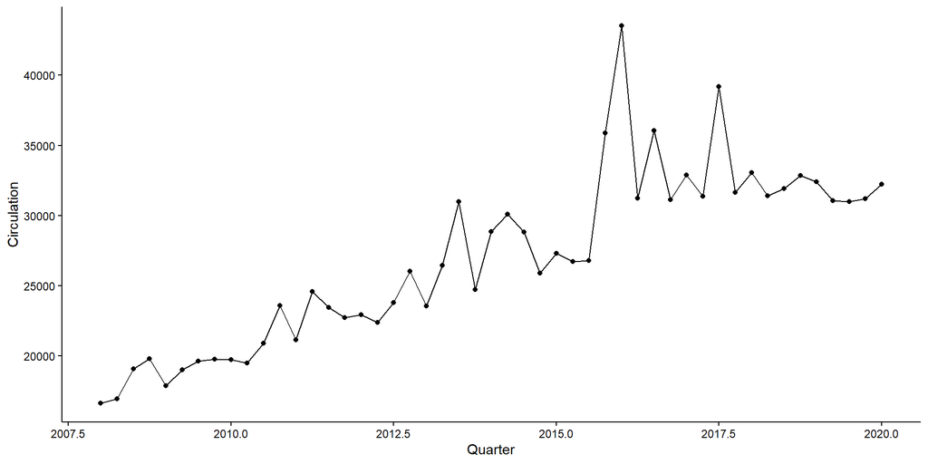

Source: Informationsgemeinschaft zur Feststellung der Verbreitung von Werbeträgern (2021)

## All topics, part 1

```
A topic model with 30 topics, 5695 documents and a 4777 word dictionary.
```

```
     National identity Immigration policy Integration/\ncitizenship Terrorism
[1,] "volk"            "einwander"        "integration"             "islamist"
[2,] "kultur"          "einwand"          "einwand"                 "anschlag"
[3,] "kulturell"       "asyl"             "staatsburgerschaft"      "terrorist"
[4,] "identitat"       "illegal"          "zuwander"                "terror"
[5,] "begriff"         "paulwitz"         "staatsangehor"           "attentat"
     Asylum        Religion   International immigration
[1,] "asylbewerb"  "islam"    "migration"
[2,] "abschiebung" "muslim"   "international"
[3,] "behord"      "religion" "migrant"
[4,] "asyl"        "moslem"   "global"
[5,] "zustand"     "religios" "pakt"
```

## All topics, part 2

```
     Ethnic violence         Illegal\nimmigration Economy     Demography
[1,] "jugend"                "illegal"            "milliard"  "bevolker"
[2,] "schul"                 "afrikan"            "geld"      "anteil"
[3,] "gewalt"                "migrant"            "unternehm" "demograph"
[4,] "migrationshintergrund" "afrika"             "kost"      "statist"
[5,] "spiel"                 "schiff"             "bank"      "studi"
     Crime      Welfare state
[1,] "polizei"  "hartz"
[2,] "tat"      "iv"
[3,] "opfer"    "arbeitslos"
[4,] "polizist" "leistung"
[5,] "straftat" "anspruch"
```

## Terror and crime topics

- Terrorism (islamist, attack, terror)
- Crime (police, offense, victim)
- Ethnic violence (youth, violence, migration background, arab)

## Culture and economic topics

- Religion (islam, muslim, christ)
- National identitiy (volk, culture, identitiy, nation, history)
- Welfare state (hartz, unemployed, benefit, claim)
- Economy (billion, money, company, cost)

## Demography topic

- Terms: *population, share, studies, development*
- Example: *The pyramid becomes a tombstone - Germany 2050: The population projection of the Federal Statistical Office offers gloomy prospects for criticism* (Zach in Junge Freiheit 26/03; 20 Jun 2003)

## Other immigration topics

- International immigration (global, migrant, pact, un)
- Integration (integration, citizenship)
- “Illegal” immigration (illegal, africa, ship)

## Topic prevalence

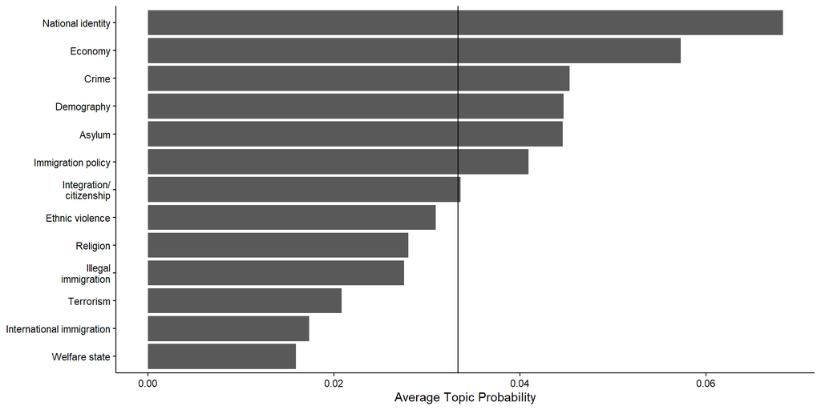